# IE 360 Homework 1

Ayca Ilhan

2022-04-10

## INTRODUCTION

Since 2013,Turkey has been facing an upward trend of USD/TRY exchange rate. There are many reasons behind it, including political decisions, import/export balances, investments etc. Recently this trend has gotten steeper, resulting in huge price changes in the country. One of the reasons for this steep rise is something the world shares in common, Covid-19. In 2020, the whole world experienced an unprecedented pandemic called Covid-19. This has changed many things including how people live, work; what people consume, like and care. In other words it altered the economical structure of the world, resulting in many working facilities to shut down, high inflation rates, change in demand, high unemployment rates etc. Eventually Turkey, which is one of the still developing countries in the world, has faced the same difficulties as well. After the heavy wreck that Covid-19 left on top of its upward USD/TRY trend, Turkish Lira has gone up more than ever. But Frankly, Covid-19 is not the only reason behind this. For almost 10 years Turkey’s production on many fields has become more dependent abroad. On the other hand, since Turkey has been embracing a huge population, its unemployment rates keep changing due to its non stationary situation. Also since one of the price indicators PPI is increasing, Turkey’s industrial environment is facing many company’s shutdowns causing higher unemployment rates.  
In this time series analysis work. I will be analyzing the following questions:

- How has the USD/TRY exchange rate changed?
- Due to the USD/TRY rate and Turkey’s industrial raw materials needs, how has the Producer Price Index changed?
- How has the Industrial Production Index changed?
- How has unemployment status/rates responded to this?
- How is the relationship between these different data sets in terms of correlation?

All of these questions will be answered in terms of data provided from a system which the Central Bank of the Republic of Turkey provides on their Electronic Data Delivery System: [EVDS](https://evds2.tcmb.gov.tr/).

USD/TRY exchange rate, Producer Price Index (PPI) which indicates production cost values based on a year, Industry Production Index (IPI) in Turkey which show the amount of products produced in Turkey, Unemployment Rate in Turkey is selected.

Also to see how people have responded to these price changes and high inflation, I will be analyzing Google Search Data for the word “enflasyon”.

My data sets are on monthly basis and belong to a time horizon between January 2016 to December 2021.

```r
library(readxl)
library(ggplot2)
library(dplyr)
library(tidyr)
library(lubridate)
library(RColorBrewer)
library(zoo)
library(GGally)
library(xts)
library(RColorBrewer)
```

## Data Manipulation

First all of the data is prepared to have proper data sets:

```r
#DATA PREPARATION

#Montly Dollar/TRY rates between 2016 and 2022
dolar<-read_excel("C:\\Users\\ilker\\Downloads\\EVDS.xlsx")
dolar[,3]<-NULL
dolar<-dolar[-c(73:81),]
dolar<-dolar%>%dplyr::rename(Date=Tarih, DolarToTRY=`TP DK USD A YTL`)%>%
  mutate(Date=as.Date(as.yearmon(Date)))
dolar$DolarToTRY<-as.numeric(dolar$DolarToTRY)
str(dolar)

#Monthly Producer Price Index values (PPI) between 2016 and 2022
PPI<-read_excel("C:\\Users\\ilker\\Downloads\\EVDS (2).xlsx")
PPI[,3]<-NULL
PPI<-PPI[-c(73:85),]
PPI<-PPI%>%dplyr::rename(Date=Tarih,PPI=`TP TUFE1YI T1`)%>%
  mutate(Date=as.Date(as.yearmon(Date)))
PPI$PPI<-as.numeric(PPI$PPI)
str(PPI)

#Industrial Producer Index (IPI)
IPI<-read_excel("C:\\Users\\ilker\\Downloads\\EVDS (11).xlsx")
IPI[,3]<-NULL
IPI<-IPI[-c(73:85),]
IPI<-IPI%>%dplyr::rename(Date=Tarih,IPI=`TP SANAYREV4 Y1`)%>%
  mutate(Date=as.Date(as.yearmon(Date)))
IPI$IPI<-as.numeric(IPI$IPI)
str(IPI)

#Monthly Unemployment rates between 2016 and 2022
unemployment<-read_excel("C:\\Users\\ilker\\Downloads\\EVDS (4).xlsx")
unemployment[,3]<-NULL
unemployment<-unemployment[-c(73:85),]
unemployment<-unemployment%>%dplyr::rename(Date=Tarih,UnemploymentRate=`TP YISGUCU2 G8`)%>%
  mutate(Date=as.Date(as.yearmon(Date)))
unemployment$UnemploymentRate<-as.numeric(unemployment$UnemploymentRate)
str(unemployment)

#GOOGLE Search for "enflasyon"
inflation_search<-read.csv("C:\\Users\\ilker\\Downloads\\multiTimeline (3).csv")
inflation_search<-inflation_search[-c(73),]
inflation_search<-inflation_search%>%dplyr::rename(Date=Ay)%>%
  mutate(Date=as.Date(as.yearmon(Date)))
inflation_search$enflasyon<-as.numeric(inflation_search$enflasyon)
str(inflation_search)
```

# DATA VISUALIZATION AND INTERPRETATION

## 1.Analysis of USD/TRY Exchange Rate

### 1.1 Time Series Plot of USD/TRY

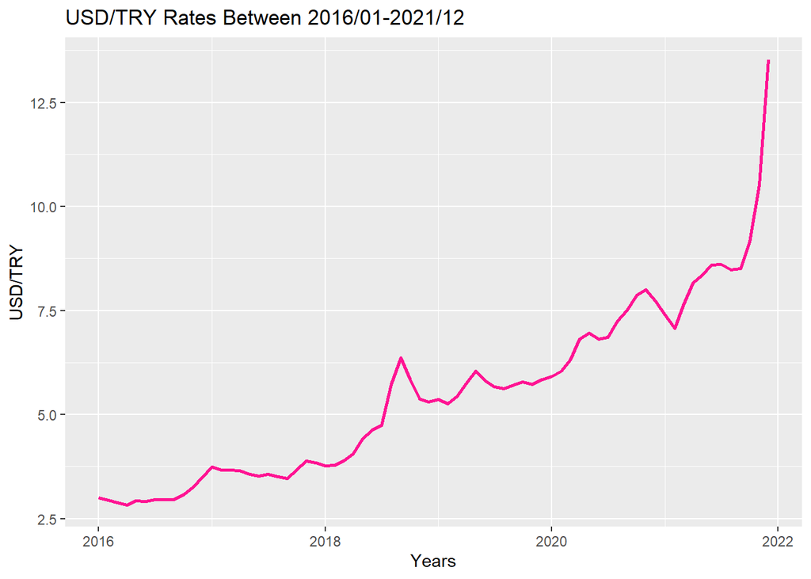

```r
#dollar exchange rate plot
ggplot(dolar, aes(Date,DolarToTRY))+geom_line(size=1, color="#FF1493")+theme_gray()+
  ggtitle("USD/TRY Rates Between 2016/01-2021/12")+xlab("Years")+ylab("USD/TRY")
```

*Figure 1. USD/TRY trend over the years (2016-2022)*

As it can be seen from the plot Dollar/TRY rate has an increasing trend since 2016 and this trend becomes steeper since late 2021 and there is a peak in the middle of 2018. Besides there is a slight decrease in 2021, trend then became steeper.

### 1.2 Histogram of USD/TRY Exchange Rate

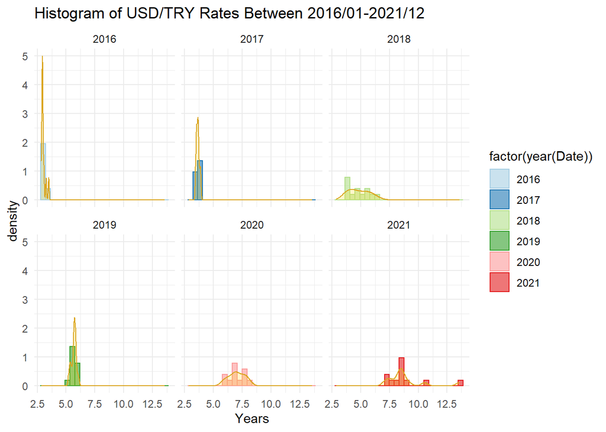

```r
#dollar histogram
ggplot(dolar, aes(DolarToTRY))+geom_histogram(alpha=0.6,bins=26,aes(y=..density..,fill=factor(year(Date)), color=factor(year(Date))))+
  geom_density(alpha=0.2, fill="gold", color="golden rod")+
  facet_wrap(~year(Date))+ggtitle("Histogram of USD/TRY Rates Between 2016/01-2021/12")+xlab("Years")+ylab("density")+
  theme(legend.position="none",axis.ticks.x=element_blank())+theme_minimal()+scale_color_brewer(palette="Paired")+scale_fill_brewer(palette="Paired")
```

*Figure 2. USD/TRY distribution over the years (2016-2022)*

As it is illustrated in Figure 2, in the first years USD/TRY distribution seems to be very narrow, showing very little variation, but after the sudden peak appeared in 2018 the variation seems to become wider. This indicates a wider range of USD/TRY rate throughout the year. Later on even though it seems to become narrower again, for the last to years the variation illustrates an increase. In general, distribution seems shifting towards right as it is a representation of the trend.

### 1.3 Box-Plot of USD/TRY Exchange Rate

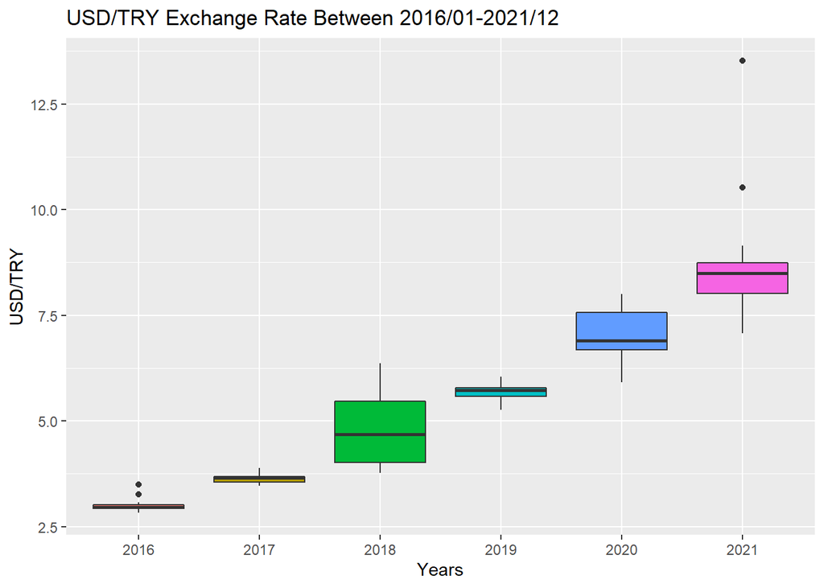

```r
#dollar box plot
ggplot(dolar, aes(factor(year(Date)),DolarToTRY))+geom_boxplot(aes(fill=factor(year(Date))))+
  ggtitle("USD/TRY Exchange Rate Between 2016/01-2021/12")+xlab("Years")+
  ylab("USD/TRY")+
  theme(legend.position="none")
```

*Figure 3. USD/TRY change over the years (2016-2022)*

Variation over the years and narrow variation becoming wider can be clearly seen from Figure 3, 2018 and 2020 shows wider box-plots representing the sudden changes in USD/TRY rate. Since the trend becomes steeper in late 2021, this is illustrated as outlier points in the box-plot. Besides, the upward trend is illustrated as the median value tends to move upwards each year.

## 2.Analysis of Producer Price Index (PPI)

### 2.1 Time Series Plot of Producer Price Index

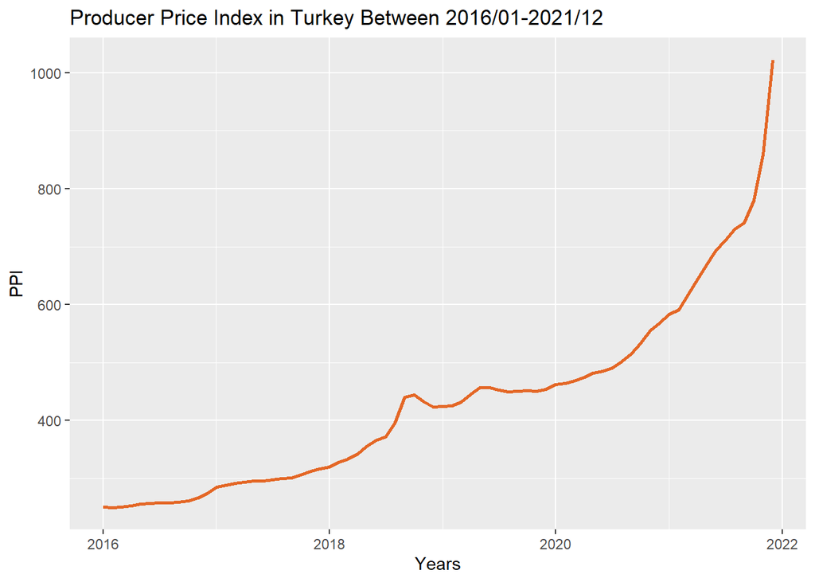

```r
#PPI plot
ggplot(PPI, aes(Date,PPI))+geom_line(size=1, color="#E46726")+theme_grey()+
  ggtitle("Producer Price Index in Turkey Between 2016/01-2021/12")+xlab("Years")+ylab("PPI")
```

*Figure 4 . PPI over the years (2016-2022)*

Producer Price Index, which is one of the main price indicators has been increasing with an increasing trend shown in Figure 4 since 2016 as well . It has a small peak in 2018 at the time when USD/TRY rate had gone up. Besides, it can bee seen that PPI doesn’t tend to response back to small decreases like occurred in USD/TRY rates.

### 2.2 Histogram of Producer Price Index

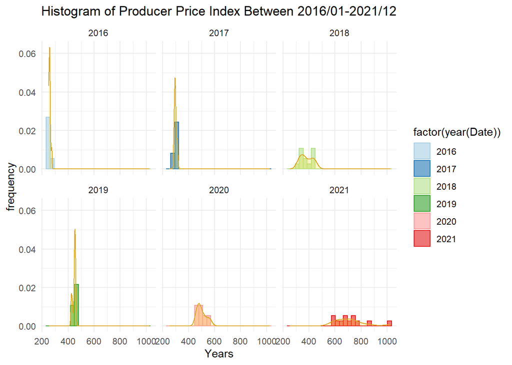

```r
#PPI histogram
ggplot(PPI, aes(PPI))+geom_histogram(alpha=0.6,bins=26,aes(y=..density..,fill=factor(year(Date)), color=factor(year(Date))))+
  geom_density(alpha=0.2, fill="gold", color="golden rod")+
  facet_wrap(~year(Date))+ggtitle("Histogram of Producer Price Index Between 2016/01-2021/12")+xlab("Years")+ylab("frequency")+
  theme(legend.position="none",axis.ticks.x=element_blank())+theme_minimal()+scale_color_brewer(palette="Paired")+scale_fill_brewer(palette="Paired")
```

*Figure 5. PPI distribution over the years (2016-2022)*

From Figure 5, it can be seen that PPI distribution behaves like USD/TRY rate. Since both of them have a similar trend, their variation shifts and overall shifting towards the right due to an increase in the trend can be observed from the histogram.

### 2.3 Box-Plot of Producer Price Index

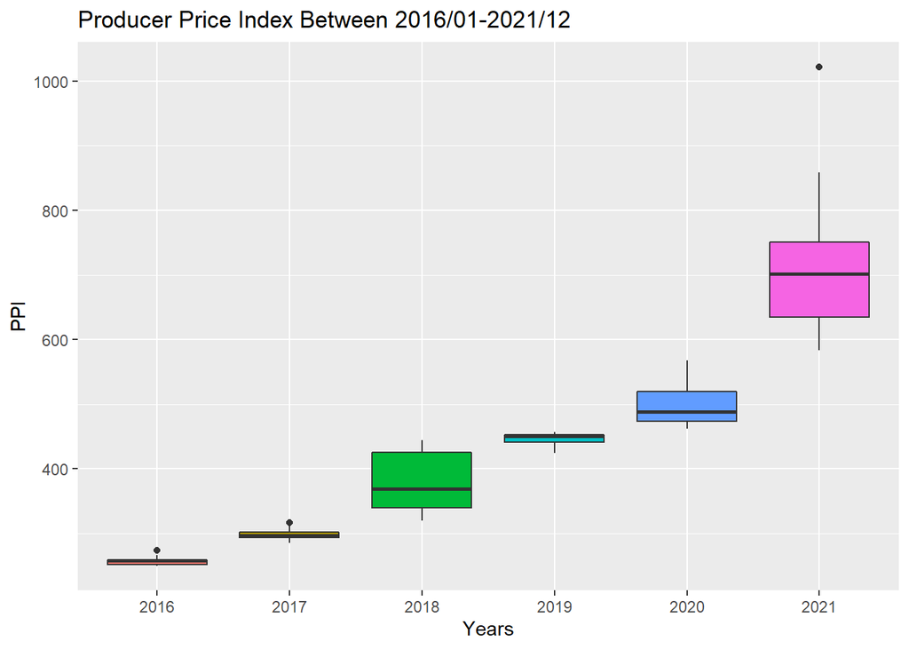

```r
#PPI box plot
ggplot(PPI, aes(factor(year(Date)),PPI))+geom_boxplot(aes(fill=factor(year(Date))))+
  ggtitle("Producer Price Index Between 2016/01-2021/12")+xlab("Years")+
  ylab("PPI")+
  theme(legend.position="none")
```

*Figure 6. PPI change over the years (2016-2022)*

Also by looking at Figure 6, wider variations in 2018, 2020 and 2021 can be seen. Unlike USD/TRY rate PPI has a wider box-plot in 2021 rather than 2020. Also the steepness of the trend of late 2021 is again reflected as an outlier point in the box-plot.

## 3. Analysis of Industry Production Index

### 3.1 Time Series Plot of Industry Production Index

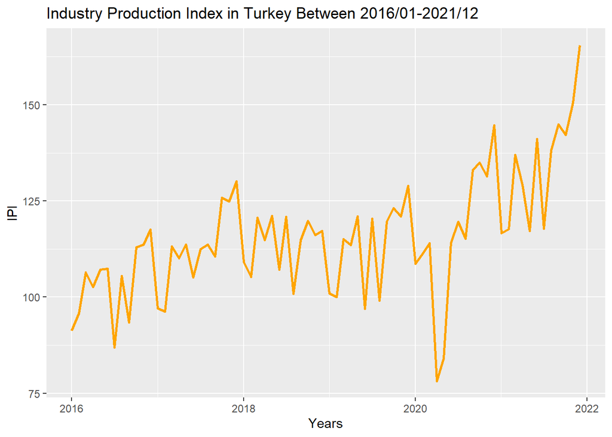

```r
#IPI plot
ggplot(IPI, aes(Date,IPI))+geom_line(size=1, color="orange")+theme_grey()+
  ggtitle("Industry Production Index in Turkey Between 2016/01-2021/12")+xlab("Years")+ylab("IPI")
```

Unlike USD/TRY rate and PPI, industry production index doesn’t show neither steady upward nor downward trend. There is a dramatic decrease in 2020. This may happen due to Covid-19. Since late 2021 an upward going trend can be seen from the graph. Overall, there are patterns with combinations of upward and downward trends.

### 3.2 Histogram of Industry Production Index

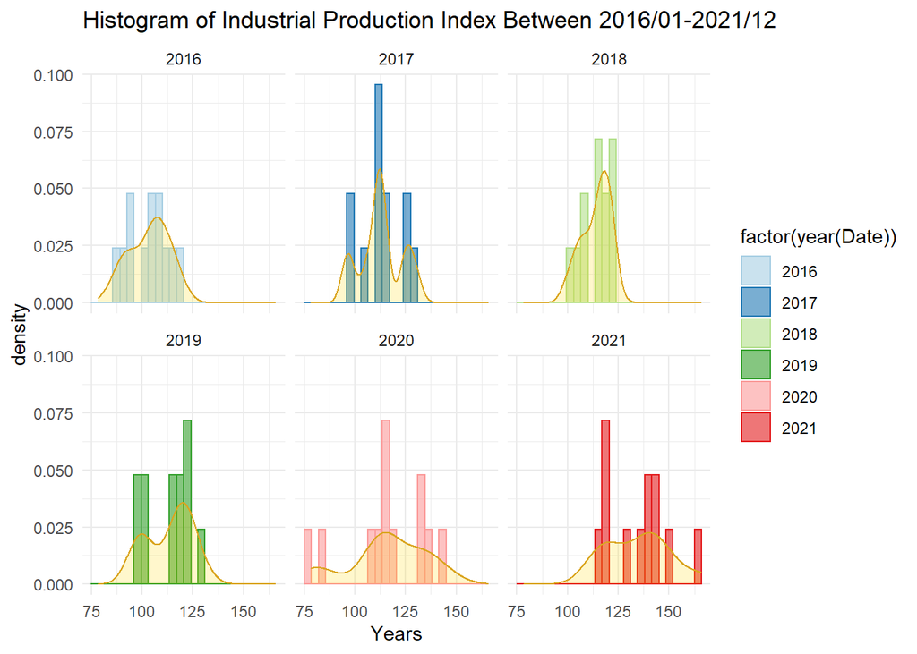

```r
#IPI histogram
ggplot(IPI, aes(IPI))+geom_histogram(alpha=0.6,bins=26,aes(y=..density..,fill=factor(year(Date)), color=factor(year(Date))))+
  geom_density(alpha=0.2, fill="gold", color="golden rod")+
  facet_wrap(~year(Date))+ggtitle("Histogram of Industrial Production Index Between 2016/01-2021/12")+xlab("Years")+ylab("density")+
  theme(legend.position="none")+theme_minimal()+scale_color_brewer(palette="Paired")+scale_fill_brewer(palette="Paired")
```

*Figure 8. IPI distribution over the years (2016-2022)*

Distribution of IPI does not seem normally distributed. Its variance is not constant too. But for the last two years its variance got wider. Especially in 2020.

### 3.3 Box-Plot of Industry Production Index

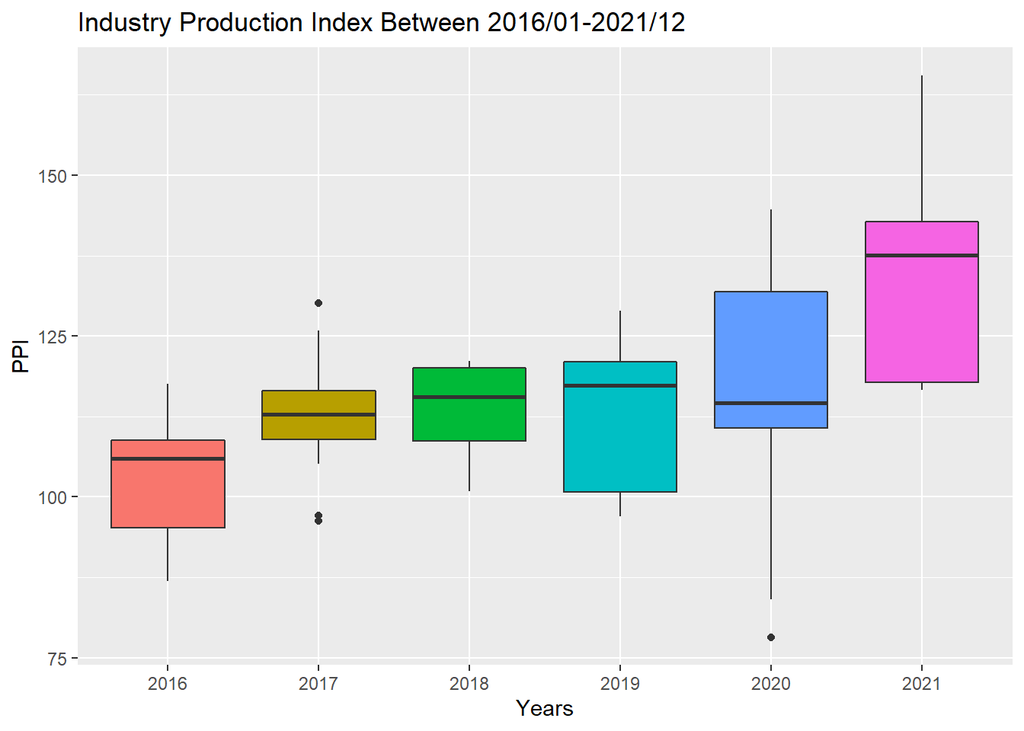

```r
#IPI box plot
ggplot(IPI, aes(factor(year(Date)),IPI))+geom_boxplot(aes(fill=factor(year(Date))))+
  ggtitle("Industry Production Index Between 2016/01-2021/12")+xlab("Years")+
  ylab("PPI")+
  theme(legend.position="none")
```

*Figure 9. IPI change over the years (2016-2022)*

Covid-19 effect is reflected in 2020 as an outlier and this effect of it may had lasted for the rest of the year since the median value shifted downwards. Since 2018 the variance keeps getting wider.

## 4. Analysis of Unemployment Rates

### 4.1 Time Series Plot of Unemployment Rates

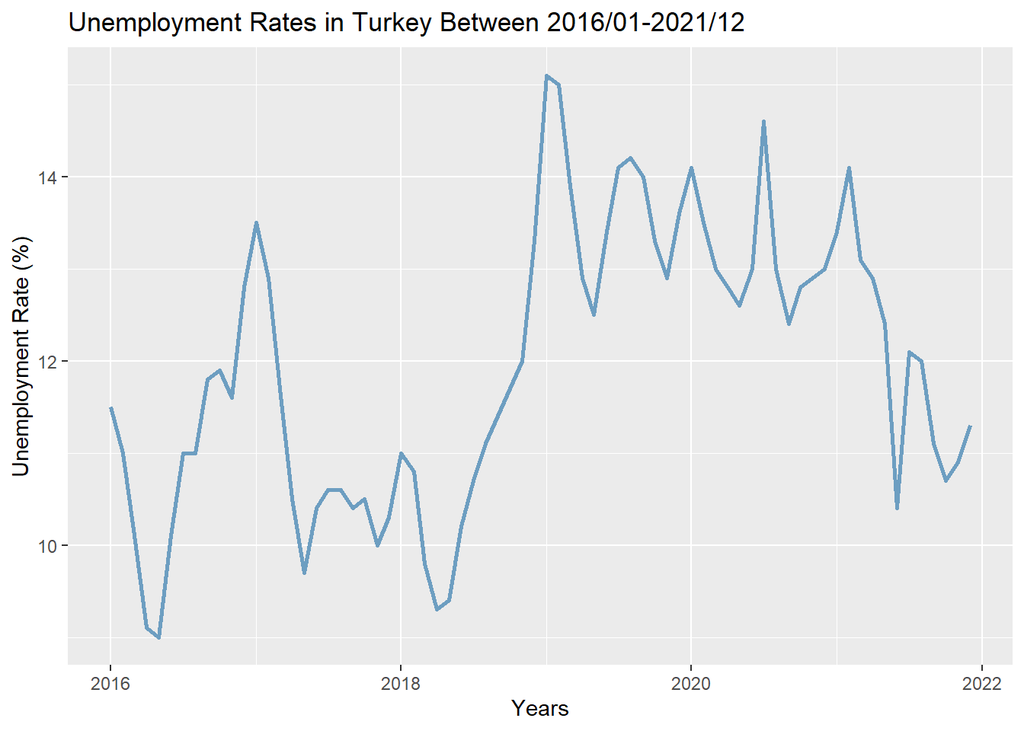

```r
#unemployment plot
ggplot(unemployment, aes(Date,UnemploymentRate))+geom_line(size=1, color="#6D9EC1")+theme_grey()+
  ggtitle("Unemployment Rates in Turkey Between 2016/01-2021/12")+xlab("Years")+ylab("Unemployment Rate (%)")
```

*Figure 10. Unemployment Rates over the years (2016-2022)*

### 4.2 Histogram of Unemployment Rate

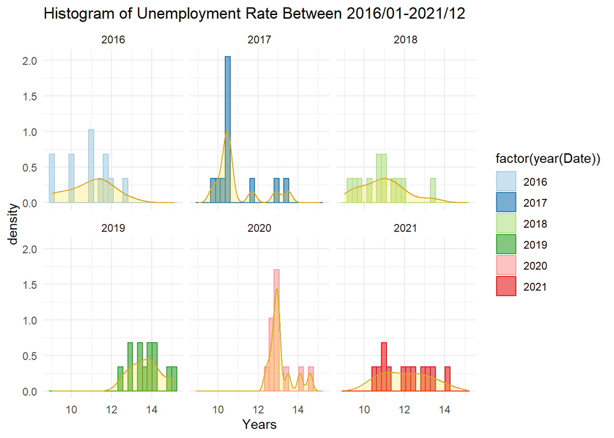

```r
#unemployment histogram
ggplot(unemployment, aes(UnemploymentRate))+geom_histogram(alpha=0.6,bins=26,aes(y=..density..,fill=factor(year(Date)), color=factor(year(Date))))+
  geom_density(alpha=0.2, fill="gold", color="golden rod")+
  facet_wrap(~year(Date))+ggtitle("Histogram of Unemployment Rate Between 2016/01-2021/12")+xlab("Years")+ylab("density")+
  theme(legend.position="none")+theme_minimal()+scale_color_brewer(palette="Paired")+scale_fill_brewer(palette="Paired")
```

*Figure 11. Unemployment Rate distribution over the years (2016-2022)*

Like it is can be seen in IPI histogram, unemployment rate throughout the years does not seem to be distributed normally. Its variance keeps changing over the years. Besides 2018 and 2021 has the largest variance, where as in 2019 shift towards right represents the sudden change.

### 4.3 Box-Plot of Unemployment Rate

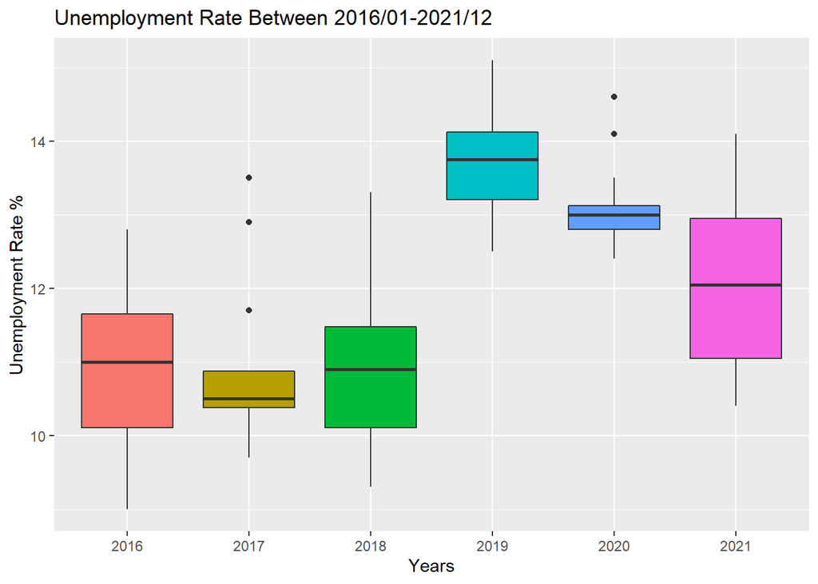

```r
#Unemployment rate box plot
ggplot(unemployment, aes(factor(year(Date)),UnemploymentRate))+geom_boxplot(aes(fill=factor(year(Date))))+
  ggtitle("Unemployment Rate Between 2016/01-2021/12")+xlab("Years")+
  ylab("Unemployment Rate %")+
  theme(legend.position="none")
```

*Figure 12. Unemployment Rate box-plot over the years (2016-2022)*

Sudden peaks are represented by outliers for the years 2017 and 2020. Since there are many oscillations in the data this is reflected by wide box-plots. The widest box-plot belongs to 2021. This may be due to the Covid-19 effect.

## 5. Analysis of “Enflasyon” Google Search Volume

### 5.1 Time Series Plot of “Enflasyon” Google Search Volume

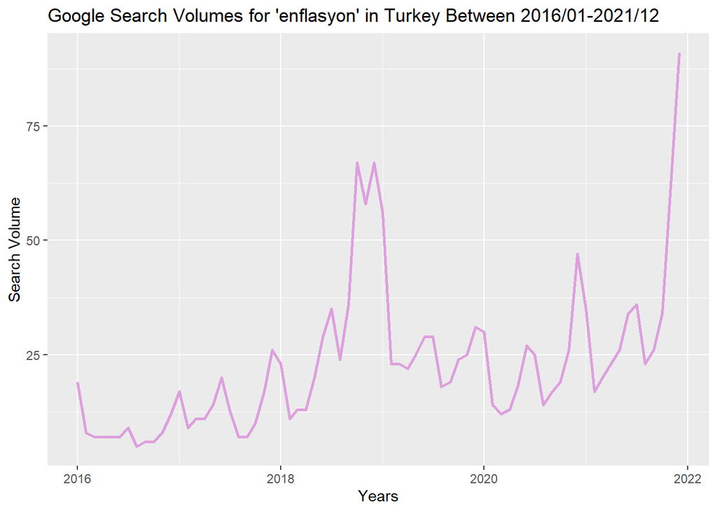

```r
#"enflasyon" search plot
ggplot(inflation_search, aes(Date,enflasyon))+geom_line(size=1, color="#DDA0DD")+theme_grey()+
  ggtitle("Google Search Volumes for 'enflasyon' in Turkey Between 2016/01-2021/12")+xlab("Years")+ylab("Search Volume")
```

*Figure 13. “Enflasyon” Google Search Volume over the years (2016-2022)*

Overall, search volume for the word “enflasyon” has an upward trend with some steep increases. Time of these increases happen to correspond to times where the USD/TRY rate makes a peak. To understand the correlation between them we need to do correlation analysis as well. But for now, it can be seen that “enflasyon” search is increasing, meaning that people wonder more about inflation and this may have peaks due to some sudden changes.

### 5.2 Histogram of “Enflasyon” Google Search

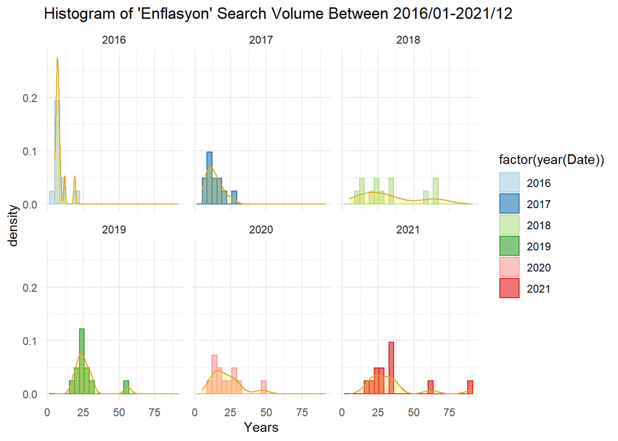

```r
#"enflasyon search" histogram
ggplot(inflation_search, aes(enflasyon))+geom_histogram(alpha=0.6,bins=26,aes(y=..density..,fill=factor(year(Date)), color=factor(year(Date))))+
  geom_density(alpha=0.2, fill="gold", color="golden rod")+
  facet_wrap(~year(Date))+ggtitle("Histogram of 'Enflasyon' Search Volume Between 2016/01-2021/12")+xlab("Years")+ylab("density")+
  theme(legend.position="none")+theme_minimal()+scale_color_brewer(palette="Paired")+scale_fill_brewer(palette="Paired")
```

Figure 14. “Enflasyon” Google Search distribution over the years (2016-2022)

### 5.3 Box-Plot of “Enflasyon” Google Search

[figure not shown]

```r
#"enflasyon" search box plot
ggplot(inflation_search, aes(factor(year(Date)),enflasyon))+geom_boxplot(aes(fill=factor(year(Date))))+
  ggtitle("'enflasyon' Google Search Volume Between 2016/01-2021/12")+xlab("Years")+
  ylab("'Enflasyon' Search Volume in Turkey")+
  theme(legend.position="none")
```

Figure 15. “enflasyon” search volume box-plot over the years (2016-2022) Figure 15 box-plot illustrates sudden increases in the search as outliers throughout the years. Plus, 2018 has the widest box-plot. Since people had not experienced a sudden decrease for a long time in those times they perhaps tried to search for “enflasyon” as a reaction.

# Correlation Analysis

Correlation analysis is a method that helps to understand the relationship between different variables. In our analysis there are 5 different variables. At the beginning the aim of this work was to understand how each variable affects each other and to see how they are related if there is a relationship between them. USD/TRY exchange may lead to PPI to change its trend. Change in the PPI may cause a downwards or upwards trend on production rates. And Change in the production rates may cause change in unemployment rates. Finally people may look for the word “enflasyon” more, depending on the other variables’ situation. To answer all of these we need to do correlation analysis.

First, we have to merge data sets to do correlation analysis:

```r
##################Merging datas
sub_df<-merge(dolar,PPI,by="Date")
sub_df2<-merge(sub_df,IPI, by="Date")
sub_df3<-merge(sub_df2,unemployment, by="Date")
data_set<-merge(sub_df3,inflation_search, by="Date")
summary(data_set[,c(2:6)])
```

```
##    DolarToTRY          PPI              IPI         UnemploymentRate
##  Min.   : 2.835   Min.   : 250.2   Min.   : 78.22   Min.   : 9.00
##  1st Qu.: 3.660   1st Qu.: 297.1   1st Qu.:106.93   1st Qu.:10.68
##  Median : 5.533   Median : 432.3   Median :114.85   Median :11.95
##  Mean   : 5.499   Mean   : 433.5   Mean   :115.69   Mean   :11.94
##  3rd Qu.: 6.876   3rd Qu.: 486.6   3rd Qu.:121.03   3rd Qu.:13.00
##  Max.   :13.528   Max.   :1022.2   Max.   :165.56   Max.   :15.10
##    enflasyon
##  Min.   : 5.00
##  1st Qu.:12.00
##  Median :20.00
##  Mean   :23.22
##  3rd Qu.:27.50
##  Max.   :91.00
```

```r
timeseries_data<-xts(data_set[,-1], order.by=as.Date(data_set[,1], "%Y/%m/%d"))
```

## Pairwise Correlation Analysis

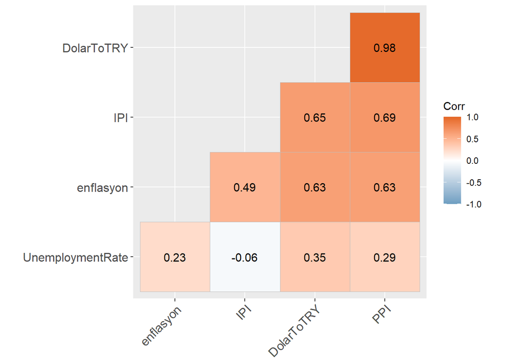

```r
#Correlation Analysis
library(ggcorrplot)
corr_analysis=cor(data_set[,c(2:6)])
#correlation value between each data
ggcorrplot(corr_analysis,hc.order=TRUE,type="lower",lab=TRUE, colors=c("#6D9EC1","white","#E46726"),ggtheme = ggplot2::theme_gray)
```

*Figure 16. Correlation values of each variables*

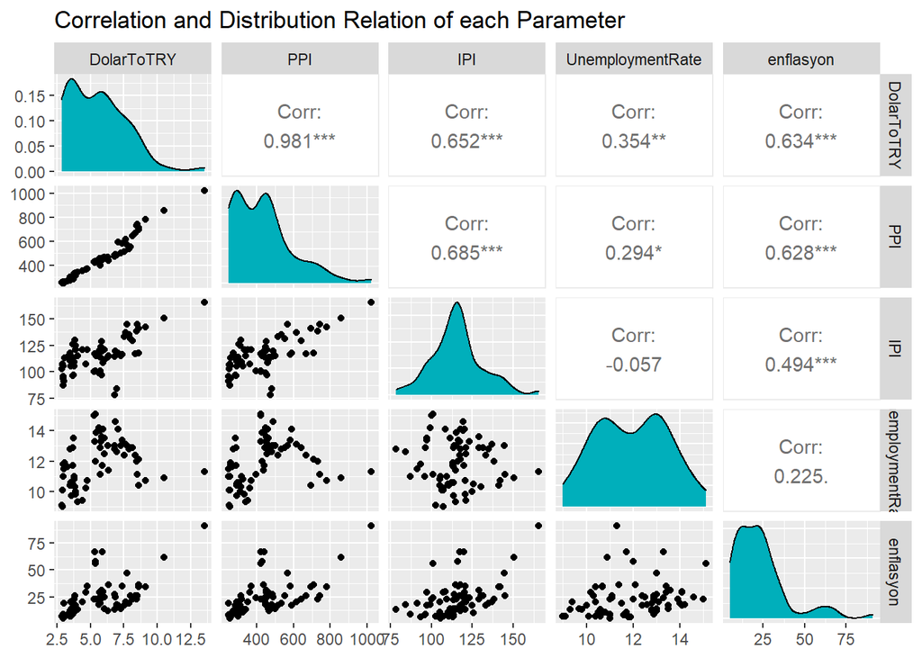

```r
#distribution, correlation values all together
ggpairs(data_set[,c(2:6)],ggplot2::aes(fill="#C4961A"))+scale_fill_manual(values = "#00AFBB")+ggtitle("Correlation and Distribution Relation of each Parameter")
```

*Figure 17, Pairwise correlation and ggpairs plot*

In Figure 17, it can be easily seen that PPI and USD/TRY have very similar distribution shapes. Both of them have right skewed distributions. Also their high correlation is represented by a linear scatter plot in the figure as well. Search volume for “enflasyon” seems to have a right skewed distribution like PPI and USD/TRY as well. Also its pretty high positive correlation with those variables can be observed from the scatter plots. But those scatter plots are not quite linear. Almost 0 correlation between IPI and unemployment rate is clearly seen from the scatter plot. Also the distribution of IPI seems to be more normal compared to others but it doesn’t show any similarity with neither unemployment rate distribution nor the others.

# CONCLUSION

## General Comparison

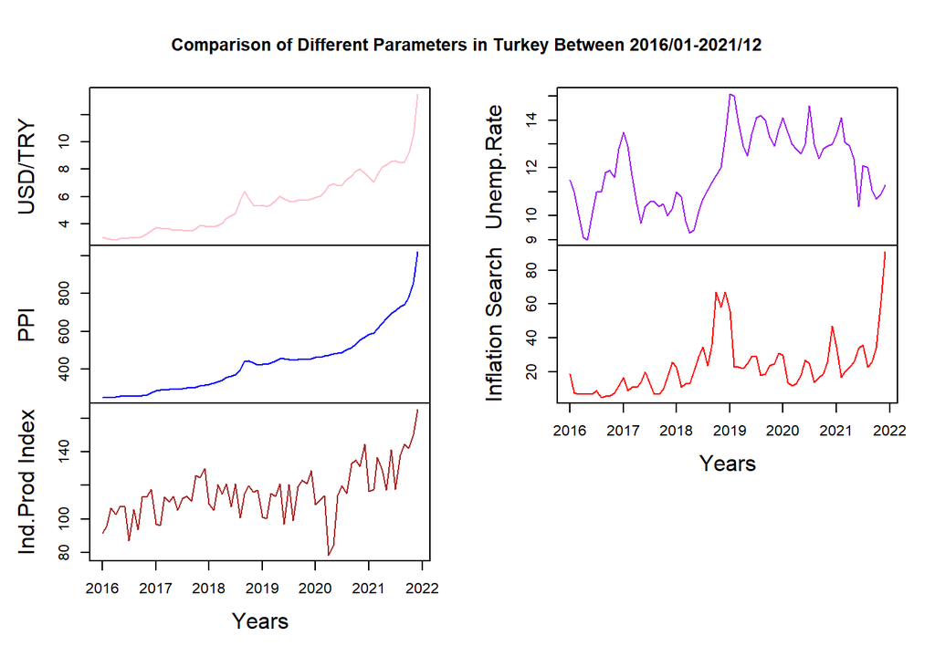

```r
columns<-c("USD/TRY","PPI","Ind.Prod Index","Unemp.Rate","Inflation Search")
cols<-c("pink","blue","brown","purple","red","orange")
#All of the time series in a graph for making comparison
plot(zoo(timeseries_data), main="Comparison of Different Parameters in Turkey Between 2016/01-2021/12",xlab="Years",ylab=columns, col=cols)
```

*Figure 20. Combined trend line plots*

- *How has the USD/TRY exchange rate changed?*
- *Due to the USD/TRY rate and Turkey’s industrial raw materials needs, how has the Producer Price Index changed?*
- *How has the Industrial Production Index changed?*
- *How has unemployment status/rates responded to this?*
- *How is the relationship between these different data sets in terms of correlation?*

Individual variable analysis with the help of histograms, box-plots and pairwise correlation analysis were done.

## References

Electronic Data Delivery System: [EVDS](https://evds2.tcmb.gov.tr/), [Google Trends](http://trends.google.com/)